# Les défis de la transformation digitale dans l’agroalimentaire

## La relation entre la transformation numérique et l'industrie agroalimentaire

Un point important de la transformation numérique dans le développement de l’industrie agroalimentaire est l’interconnexion entre les différentes activités exercées dans les organisations. Cela permet d’augmenter la performance des processus dans les entreprises.

De plus, grâce à l’utilisation intelligente des nouvelles technologies, l’Industrie agroalimentaire contribue à l’évolution de l’ensemble du marché, améliore l’efficacité des organisations et relève leurs indices de qualité. Cette modernisation génère des impacts dans différents domaines, tels que la logistique, les ventes, les processus de production, la gestion financière, etc.

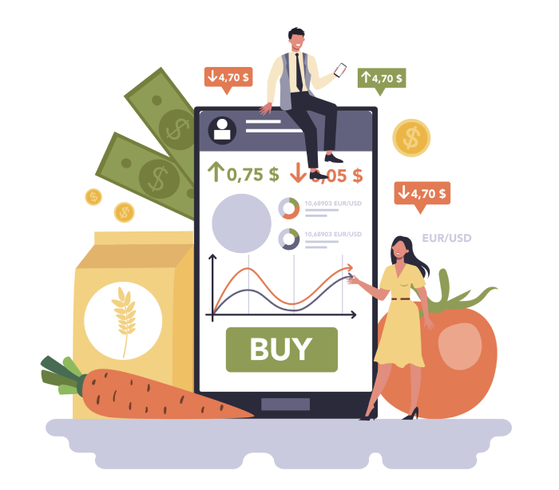

De plus, l’émergence de nouvelles fonctionnalités qui optimisent les processus dans les organisations permet une collecte de données efficace. Avec cette information en main, les gestionnaires sont plus précis lorsqu’ils prennent des décisions.

La transformation digitale dans l’industrie agroalimentaire vise à rendre la chaine de valeur efficace, intelligente et transparente.

## Les défis de la transformation digitale dans l’industrie agroalimentaire

L’un des défis auxquels sont confrontées les entreprises concerne budgets attribués aux outils technologiques. Ces derniers doivent être appréhendés comme un investissement et non comme un centre de coût.

La crise générée par la pandémie de **COVID-19** a toutefois accéléré les processus de transformation numérique dans l’industrie agroalimentaire. Cet événement a contribué à des innovations dans la manière de produire, comme les achats et le paiement en ligne.

Un autre principal défi de cette transformation numérique concerne la réduction des impacts. En ce moment, il est essentiel d’investir dans la transformation numérique, car elle aide différentes entreprises à réduire les impacts de la crise. De plus, cela assure également plus d’agilité dans les processus et pousse à la recherche d’améliorations dans la gestion.

Ce qu’il faut considérer, c’est que les entreprises ont changé leur relation avec les clients et ont dû trouver des alternatives pour poursuivre le processus de production. Avec cela, en plus des solutions de gestion en matière financière pour garantir les profits, il fallait aussi se mettre à jour technologiquement.

En pratique, ceux qui n’investissent pas dans des avancées technologiques finiront par être dépassées sur le marché.

## En conclusion

On sait déjà qu’investir dans la technologie présente plusieurs avantages Généralement, ils sont liés à l’amélioration de la production, de la gestion, de la maintenance industrielle, du suivi, de l’agilité dans les tâches, etc. Sur un secteur très concurrentiel, c’est aussi un moyen de se démarquer.

**Alors, qu’attendez-vous ?**

[figure not shown]

[figure not shown]

[figure not shown]